# 0205

### Defining functions

Sometimes it is useful to define a function in R if you are going to be making the same calculation over and over again. For example, calculating the logit (log odds) of a probability p:

```r
p <- .7
log(p/(1-p))

p <- .1
log(p/(1-p))
```

0.847297860387203

-2.19722457733622

Functions make it easy to automate repeated tasks like this.

```r
my_logit <- function(p){
    log(p/(1-p))
}

my_logit(.7)
my_logit(.1)
```

0.847297860387203

-2.19722457733622

This can be very useful for standardizing variables.

```r
st <- function(x){
    (x-mean(x,na.rm=TRUE))/sd(x,na.rm=TRUE)
}

d$grade.s <- st(d$grade)
```

### Estimating population probabilities

Here we use a simple logistic regression with no covariates to estimate the base probability of cocaine use in a population of studnts. The data we are using is from Add Health.

```r
d <- read.csv("https://mcmahanp.github.io/soci620/data/delinquency.csv")
head(d)
```

| male | race_white | race_black | race_american_indian | race_asian_pacificislander | race_other | hispanic | grade | fam_income | fam_logincome | ever_smoked | ever_alcohol | ever_marijuana | ever_cocaine | delinquency_agg |
| --- | --- | --- | --- | --- | --- | --- | --- | --- | --- | --- | --- | --- | --- | --- |
| 0 | 0 | 1 | 0 | 0 | 0 | 0 | NA | 55000 | 10.915107 | 1 | 1 | 1 | 0 | 5 |
| 0 | 0 | 1 | 0 | 0 | 0 | 0 | 11 | NA | NA | 1 | 1 | 0 | 0 | 4 |
| 1 | 1 | 0 | 0 | 0 | 0 | 0 | 10 | 45000 | 10.714440 | 1 | 0 | 0 | 0 | 1 |
| 1 | 0 | 1 | 0 | 0 | 0 | 0 | 12 | 9000 | 9.105091 | 1 | 0 | 1 | NA | 4 |
| 0 | 0 | 1 | 0 | 0 | 0 | 0 | 12 | 2000 | 7.601402 | 1 | 1 | 0 | 0 | 5 |
| 1 | 0 | 1 | 0 | 0 | 0 | 0 | 7 | 70000 | 11.156265 | 0 | 0 | 0 | 0 | 1 |

We use the `logit()` function as a link, and the `map2stan()` function to estimate the mode. The syntax for `map2stan()` is almost identical to `map()`, but it can estimate a much larger class of models.

(This function will take a little time to run. It is writing and compiling a C++ program to estimate our model for us.)

```r
library(rethinking)
m1 <- alist(
    ever_cocaine ~ dbinom(1,p),
    logit(p) <- a,
    a <- dnorm(0,1.5)
)
f1 <- map2stan(m1,data=d[complete.cases(d$ever_cocaine),])
precis(f1)
```

[output not shown]

```
[ 1000 / 1000 ]
```

```
   Mean StdDev lower 0.89 upper 0.89 n_eff Rhat
a -3.34   0.07      -3.44      -3.23   295    1
```

Use the `logistic()` function from the `rethinking` package to see what the estimate and credible interval mean in terms of probability.

```r
# expected percentage
logistic(coef(f1)[1])
# about 3.4%
```

**a:** 0.0343756518377527

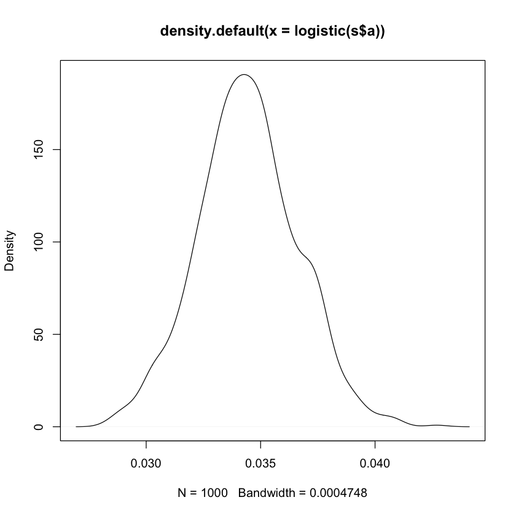

```r
# plot the density of percentages from a sample
s <- extract.samples(f1)
plot(density(logistic(s$a)))
```

For the sake of completeness, let's see what the binomial model we were using during the first week of the semester looks like with the same data. (The prior will be slightly different)

```r
# get just non-missing values of `ever_cocaine`
ec <- d$ever_cocaine[!is.na(d$ever_cocaine)]
# get number of "trials" and the number of "successes" for the binomial model
n <- length(ec)
n_true <- sum(ec)

# put it in a data frame for the estimation
d_aggregate <- data.frame(n=n,n_true=n_true)
d_aggregate
```

| n | n_true |
| --- | --- |
| 6404 | 219 |

```r
# define the model
m2 <- alist(
    n_true ~ dbinom(n,p),
    p ~ dunif(0,1)
)
# estimate using map()
f2 <- map(m2,data=d_aggregate)
precis(f2,digits=4)
```

```
    Mean StdDev   5.5%  94.5%
p 0.0342 0.0023 0.0306 0.0378
```

Compare estimates from logistic regression with the estimates from this binomial model.

```r
# regression mean
logistic(coef(f1)[1])
# binomial model mean
coef(f2)[1]
```

**a:** 0.0343756518377527

**p:** 0.0342002653245601

```r
# regression PI
logistic(PI(extract.samples(f1)$a,prob=.9))
# binomial model PI
PI(extract.samples(f2)$p,prob=.9)
```

**5%**

0.0308022923394205

**95%**

0.037942011080562

**5%**

0.0303849006897349

**95%**

0.0378136033367291